# Laboratorio 1: Introducción al tidyverse

## Ejercicio 1

Para este ejercicio vamos a trabajar con los datos `ChickWeight`, para tenerlos disponibles simplemente hacemos `data(ChickWeight)`

Los datos `ChickWeight` tienen 578 filas y 4 columnas, provienen de un experimento sobre el efecto de la dieta en el crecimiento temprano de los pollos. Se puede obtener más información sobre los datos mediante `?ChickWeight`

#### Datos completos

Cada pollo debe tener 12 observaciones, usá el paquete `dplyr` para identificar cuántos pollos tienen efectivamente los datos completos.

1. ¿Cuántos pollos tienen menos de 12 observaciones?

```r
dim(pollo %>% group_by(Chick) %>% summarise(obs=n()) %>% filter(obs<12))[1]
```

```
## [1] 5
```

2. Extrae un subconjunto de los datos correspondientes a los pollos con información completa (12 observaciones) y guardalos en un objeto llamado `complete`.

```r
complete <- left_join(pollo, (pollo %>% group_by(Chick) %>% summarise(obs=n())), by="Chick") %>% filter(obs == 12)
unique(complete$obs)
```

```
## [1] 12
```

(ayuda: usa `mutate` para crear una variable auxiliar con el número de observaciones)

#### Crear variable peso ganado

Con los datos completos, crea una nueva variable que mide la diferencia del peso en cada momento respecto del momento inicial. Llama esta variable `weightgain`.

```r
complete <- left_join(complete, (complete %>% filter(Time==0) %>% rename(Inicial = weight) %>% select(Inicial, Chick)), by="Chick") %>%
      mutate(weightgain = weight-Inicial)
```

#### Dibujar boxplot

1. Usando `ggplot2` crear un gráfico de boxplots de la variable `weightgain` contra `Diet` para el día 2.

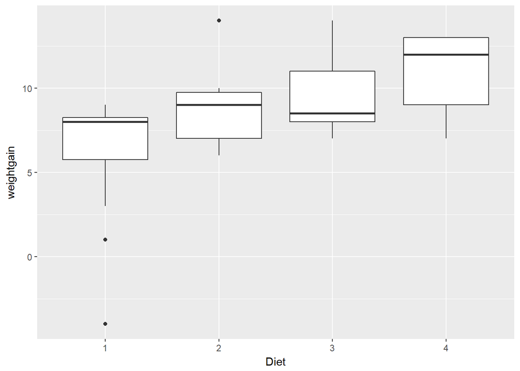

```r
ggplot(complete %>% filter(Time == 2)) +
  geom_boxplot(aes(x=Diet, y=weightgain))
```

2. Describe la relación en un par de frases.

En el gráfico cambia el orden de las categorías `Diet` de para que los boxplots queden ordenados según la mediana de `weightgain`.

[figure not shown]

```r
ggplot(complete %>% filter(Time == 2)) +
      geom_boxplot(aes(x=Diet, y=weightgain)) +
      scale_x_discrete(limits=as.numeric(((complete %>% filter(Time == 2) %>% group_by(Diet) %>% summarize(mediana=median(weightgain))) %>% arrange(mediana))$Diet))
```

#### Graficar evolución del peso

Crear un dibujo que tenga: 1. `Time` en el eje x y `weight` en el eje y. 2. Una linea para cada pollo  
3. Divide en facets y colorea según `Diet`.  
4. Incluye la leyenda debajo del dibujo (con `theme`)

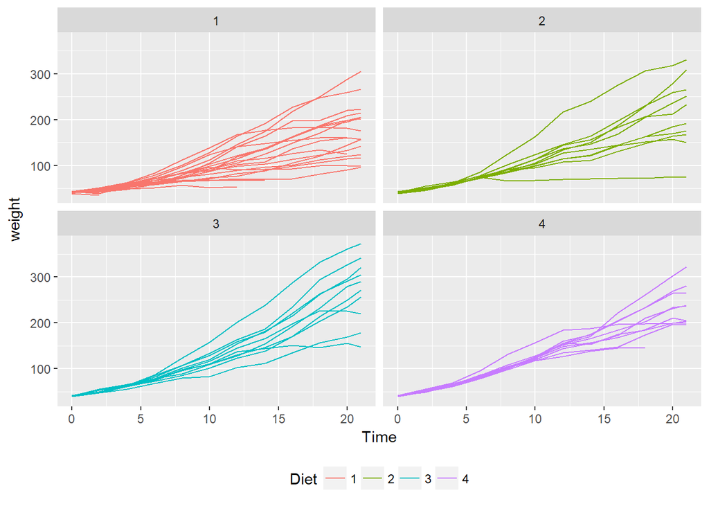

```r
ggplot(pollo) +
      geom_line(aes(x=Time, y=weight, group=Chick, colour=Diet)) +
      facet_wrap(~Diet) +
      theme(legend.position="bottom")
```

#### Graficar solo pollos más grandes

1. Seleccionar el pollo con máximo peso en el momento 21 para cada dieta.

```r
maximos <- pollo %>% filter(Time == 21) %>% group_by(Diet) %>% summarize(Mayor_peso=max(weight)) # Consigo el máximo peso por dieta para Time == 21
pollo <- left_join(pollo, maximos, by="Diet") %>% mutate(dif=weight-Mayor_peso) # Los agrego a la base "pollo" y calculo la diferencia con weight. Aquellos que tengan diferencia 0, serán los máximos.
table(pollo$dif == 0) # Verifico que sea uno solo pollo por dieta (es decir, que haya solo 4 ceros)
```

```
##
## FALSE  TRUE
##   574     4
```

```r
pollitos.gorditos <- pollo[which(pollo$dif == 0), "Chick"] # Identifico los pollos
```

2. Repetir el dibujo anterior solo con estos 4 pollos y sin facetas.

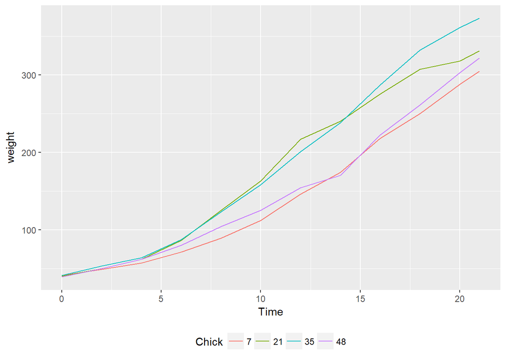

```r
ggplot(pollo %>% filter(Chick %in% pollitos.gorditos)) +
      geom_line(aes(x=Time, y=weight, color=Chick)) +
      theme(legend.position="bottom")
```

#### Ganancia de peso promedio

Calcular la ganancia de peso media diaria y repetir el dibujo.

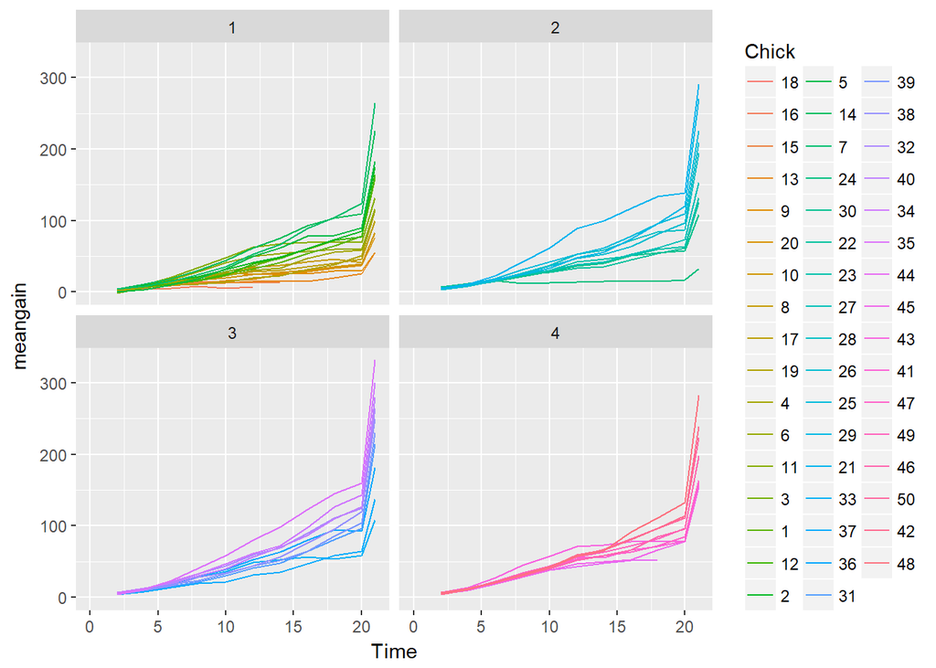

```r
pollo <- select(pollo, -Mayor_peso, -dif)
pollo <- pollo %>% group_by(Chick) %>% mutate(dif=Time-lag(Time, default=0))
pollo <- left_join(pollo, (pollo %>% filter(Time==0) %>% rename(Inicial=weight) %>% select(Inicial, Chick)), by="Chick") %>%
      mutate(weightgain = weight-Inicial)
pollo <- pollo %>% mutate(meangain=weightgain/dif)

ggplot(pollo) +
      geom_line(aes(x=Time, y=meangain, color=Chick)) +
      facet_wrap(~Diet)
```

## Ejercicio 2

Crear una función de R que: 1. Ajuste un modelo linear

```r
modelolineal <- function(x, y) {lm(y ~ x)}
```

2. Dibuje los residuos contra valores ajustados del modelo

Los argumentos de la funciÃ³n deben ser:  
`x` (variable explicativa),  
`y` (variable de respuesta)  
`col` color para la linea horizontal

La etiqueta del eje x debe ser ‘Valores ajustados’ y la etiqueta del eje y debe ser ‘Residuos’. Prueba como funciona usando `data(LifeCycleSavings)`, con `x = sr`, `y = ddpi` y `col = red`.